# Predict Bike Sharing Demand with EDA Template

### import libraries

```python
import pandas as pd
import numpy as np
import seaborn as sns
import matplotlib.pyplot as plt
import warnings
import sys
from scipy.special import boxcox

from sklearn import preprocessing, metrics, feature_selection, model_selection # Import key modules from sklearn
from sklearn.linear_model import LinearRegression # Import the Lin
from sklearn.model_selection import train_test_split, GridSearchCV
from sklearn.preprocessing import StandardScaler
from sklearn.metrics import mean_squared_error, r2_score
from sklearn.linear_model import LinearRegression, Ridge, Lasso
from sklearn.ensemble import RandomForestRegressor
warnings.filterwarnings("ignore")

import plotly.graph_objects as go
from plotly.offline import init_notebook_mode, iplot
init_notebook_mode(connected=True)

import plotly.express as px
import datetime as dt
sns.set()
%matplotlib inline
```

# Exploratory Data Analysis

### load Data

```python
train = pd.read_csv("train.csv" ,parse_dates= ['datetime'])
test = pd.read_csv("test.csv" ,parse_dates= ['datetime'])
```

## Data preparation for EDA

```python
train.head()
```

|  | datetime | season | holiday | workingday | weather | temp | atemp | humidity | windspeed | casual | registered | count |
| --- | --- | --- | --- | --- | --- | --- | --- | --- | --- | --- | --- | --- |
| 0 | 2011-01-01 00:00:00 | 1 | 0 | 0 | 1 | 9.84 | 14.395 | 81 | 0.0 | 3 | 13 | 16 |
| 1 | 2011-01-01 01:00:00 | 1 | 0 | 0 | 1 | 9.02 | 13.635 | 80 | 0.0 | 8 | 32 | 40 |
| 2 | 2011-01-01 02:00:00 | 1 | 0 | 0 | 1 | 9.02 | 13.635 | 80 | 0.0 | 5 | 27 | 32 |
| 3 | 2011-01-01 03:00:00 | 1 | 0 | 0 | 1 | 9.84 | 14.395 | 75 | 0.0 | 3 | 10 | 13 |
| 4 | 2011-01-01 04:00:00 | 1 | 0 | 0 | 1 | 9.84 | 14.395 | 75 | 0.0 | 0 | 1 | 1 |

```python
test.head()
```

|  | datetime | season | holiday | workingday | weather | temp | atemp | humidity | windspeed |
| --- | --- | --- | --- | --- | --- | --- | --- | --- | --- |
| 0 | 2011-01-20 00:00:00 | 1 | 0 | 1 | 1 | 10.66 | 11.365 | 56 | 26.0027 |
| 1 | 2011-01-20 01:00:00 | 1 | 0 | 1 | 1 | 10.66 | 13.635 | 56 | 0.0000 |
| 2 | 2011-01-20 02:00:00 | 1 | 0 | 1 | 1 | 10.66 | 13.635 | 56 | 0.0000 |
| 3 | 2011-01-20 03:00:00 | 1 | 0 | 1 | 1 | 10.66 | 12.880 | 56 | 11.0014 |
| 4 | 2011-01-20 04:00:00 | 1 | 0 | 1 | 1 | 10.66 | 12.880 | 56 | 11.0014 |

```python
# Train Data
train['dayofweek'] = train.datetime.dt.dayofweek
train['hour'] =  train.datetime.dt.hour
train['day'] =  train.datetime.dt.day
train['month'] =  train.datetime.dt.month
train['year'] =  train.datetime.dt.year
```

```python
# test Data
test['dayofweek'] = test.datetime.dt.dayofweek
test['hour'] =  test.datetime.dt.hour
test['day'] =  test.datetime.dt.day
test['month'] =  test.datetime.dt.month
test['year'] =  test.datetime.dt.year
```

```python
train.describe().T.style.background_gradient(cmap='PuBuGn')
```

|  | count | mean | std | min | 25% | 50% | 75% | max |
| --- | --- | --- | --- | --- | --- | --- | --- | --- |
| season | 10886.000000 | 2.506614 | 1.116174 | 1.000000 | 2.000000 | 3.000000 | 4.000000 | 4.000000 |
| holiday | 10886.000000 | 0.028569 | 0.166599 | 0.000000 | 0.000000 | 0.000000 | 0.000000 | 1.000000 |
| workingday | 10886.000000 | 0.680875 | 0.466159 | 0.000000 | 0.000000 | 1.000000 | 1.000000 | 1.000000 |
| weather | 10886.000000 | 1.418427 | 0.633839 | 1.000000 | 1.000000 | 1.000000 | 2.000000 | 4.000000 |
| temp | 10886.000000 | 20.230860 | 7.791590 | 0.820000 | 13.940000 | 20.500000 | 26.240000 | 41.000000 |
| atemp | 10886.000000 | 23.655084 | 8.474601 | 0.760000 | 16.665000 | 24.240000 | 31.060000 | 45.455000 |
| humidity | 10886.000000 | 61.886460 | 19.245033 | 0.000000 | 47.000000 | 62.000000 | 77.000000 | 100.000000 |
| windspeed | 10886.000000 | 12.799395 | 8.164537 | 0.000000 | 7.001500 | 12.998000 | 16.997900 | 56.996900 |
| casual | 10886.000000 | 36.021955 | 49.960477 | 0.000000 | 4.000000 | 17.000000 | 49.000000 | 367.000000 |
| registered | 10886.000000 | 155.552177 | 151.039033 | 0.000000 | 36.000000 | 118.000000 | 222.000000 | 886.000000 |
| count | 10886.000000 | 191.574132 | 181.144454 | 1.000000 | 42.000000 | 145.000000 | 284.000000 | 977.000000 |
| dayofweek | 10886.000000 | 3.013963 | 2.004585 | 0.000000 | 1.000000 | 3.000000 | 5.000000 | 6.000000 |
| hour | 10886.000000 | 11.541613 | 6.915838 | 0.000000 | 6.000000 | 12.000000 | 18.000000 | 23.000000 |
| day | 10886.000000 | 9.992559 | 5.476608 | 1.000000 | 5.000000 | 10.000000 | 15.000000 | 19.000000 |
| month | 10886.000000 | 6.521495 | 3.444373 | 1.000000 | 4.000000 | 7.000000 | 10.000000 | 12.000000 |
| year | 10886.000000 | 2011.501929 | 0.500019 | 2011.000000 | 2011.000000 | 2012.000000 | 2012.000000 | 2012.000000 |

[figure not shown]

```python
# Plot the correlation matrix using a heatmap

corrmat = train.corr()
fig, ax = plt.subplots(figsize=(12, 9))

sns.heatmap(corrmat, square=True, annot=True);
```

### From the heatmap, 'registered’ and 'casual' are highly correlated to ‘count’, 'season’ is highly correlated to ‘month’, 'atemp’ is highly correlated to ‘temp’. In addition, we know that casual + registered = count. Hence we can drop columns ‘registered’, ‘casual’, "atemp" and ‘season’.

```python
corrmat.drop(["season"],axis=0,inplace=True)
corrmat.drop(["season"],axis=1,inplace=True)
corrmat.drop(["atemp"],axis=0,inplace=True)
corrmat.drop(["atemp"],axis=1,inplace=True)
corrmat.drop(["casual"],axis=0,inplace=True)
corrmat.drop(["casual"],axis=1,inplace=True)
corrmat.drop(["registered"],axis=0,inplace=True)
corrmat.drop(["registered"],axis=1,inplace=True)
```

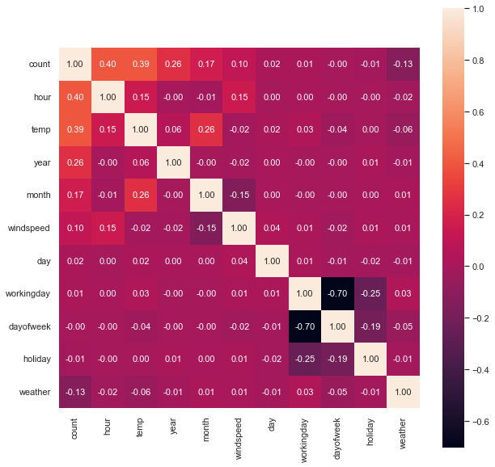

```python
# Let's now plot a "zoomed" correlation matrix, with respect to our response variable
fig, ax = plt.subplots(figsize=(10,10))
k = 11 #number of variables for heatmap
cols = corrmat.nlargest(k, 'count').loc[:,'count'].index
cm = train.loc[:,cols].corr()
sns.set(font_scale=1)
sns.heatmap(cm, cbar=True, annot=True, square=True, fmt='.2f', annot_kws={'size': 11}, yticklabels=cols.values, xticklabels=cols.values, ax=ax)
plt.show()
```

### From the above matrix, we noted that 'day', 'workingday', 'dayofweek' and 'holiday' seem to have little or no correlation to 'count'. Nevertheless, lets visualize their relationship with some plots.

```python
train.sample(10)
```

|  | datetime | season | holiday | workingday | weather | temp | atemp | humidity | windspeed | casual | registered | count | dayofweek | hour | day | month | year |
| --- | --- | --- | --- | --- | --- | --- | --- | --- | --- | --- | --- | --- | --- | --- | --- | --- | --- |
| 9070 | 2012-09-01 07:00:00 | 3 | 0 | 0 | 2 | 30.34 | 34.090 | 58 | 8.9981 | 8 | 58 | 66 | 5 | 7 | 1 | 9 | 2012 |
| 102 | 2011-01-05 11:00:00 | 1 | 0 | 1 | 1 | 10.66 | 11.365 | 33 | 22.0028 | 12 | 34 | 46 | 2 | 11 | 5 | 1 | 2011 |
| 8021 | 2012-06-14 14:00:00 | 2 | 0 | 1 | 1 | 28.70 | 32.575 | 54 | 19.0012 | 84 | 214 | 298 | 3 | 14 | 14 | 6 | 2012 |
| 8910 | 2012-08-13 15:00:00 | 3 | 0 | 1 | 1 | 33.62 | 36.365 | 34 | 15.0013 | 80 | 194 | 274 | 0 | 15 | 13 | 8 | 2012 |
| 9456 | 2012-09-17 09:00:00 | 3 | 0 | 1 | 1 | 23.78 | 27.275 | 68 | 8.9981 | 34 | 265 | 299 | 0 | 9 | 17 | 9 | 2012 |
| 7438 | 2012-05-09 07:00:00 | 2 | 0 | 1 | 2 | 22.96 | 26.515 | 94 | 12.9980 | 17 | 401 | 418 | 2 | 7 | 9 | 5 | 2012 |
| 8507 | 2012-07-15 20:00:00 | 3 | 0 | 0 | 1 | 29.52 | 34.850 | 79 | 16.9979 | 95 | 199 | 294 | 6 | 20 | 15 | 7 | 2012 |
| 3581 | 2011-08-19 03:00:00 | 3 | 0 | 1 | 1 | 26.24 | 29.545 | 78 | 0.0000 | 2 | 1 | 3 | 4 | 3 | 19 | 8 | 2011 |
| 2451 | 2011-06-10 01:00:00 | 2 | 0 | 1 | 3 | 28.70 | 32.575 | 65 | 15.0013 | 5 | 18 | 23 | 4 | 1 | 10 | 6 | 2011 |
| 518 | 2011-02-04 18:00:00 | 1 | 0 | 1 | 2 | 9.84 | 12.880 | 60 | 7.0015 | 3 | 152 | 155 | 4 | 18 | 4 | 2 | 2011 |

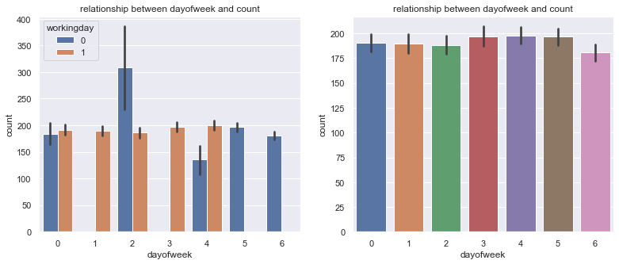

```python
#base_color = sns.color_palette()[9]
plt.figure(figsize= (13, 5))
plt.subplot(1, 2, 1)
sns.barplot(data=train, x="dayofweek", y="count", hue='workingday')
plt.title("relationship between dayofweek and count")
plt.subplot(1, 2, 2)
sns.barplot(data=train, x="dayofweek", y="count")
plt.title("relationship between dayofweek and count")

plt.show()
```

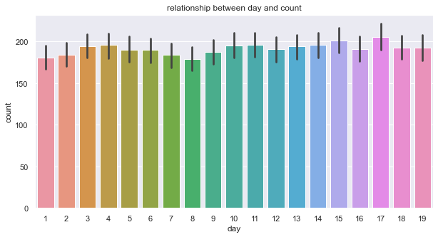

```python
plt.figure(figsize= (10, 5))
sns.barplot(data=train, x="day", y="count")
plt.title("relationship between day and count")
plt.show()
```

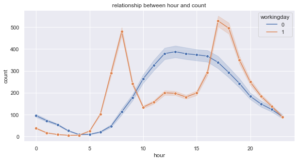

```python
plt.figure(figsize= (10, 5))
sns.lineplot(data=train, x="hour", y="count", hue='workingday', marker='o', markers=True, dashes=False)
plt.title("relationship between hour and count")
plt.show()
```

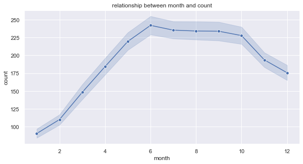

```python
plt.figure(figsize= (10, 5))
sns.lineplot(data=train, x="month", y="count", marker='o', markers=True, dashes=False)
plt.title("relationship between month and count")
plt.show()
```

### 'count' is also dependent on the 'month' of the year, where 'count' is higher from May to Oct (presumably due to warmer spring/autumn months)

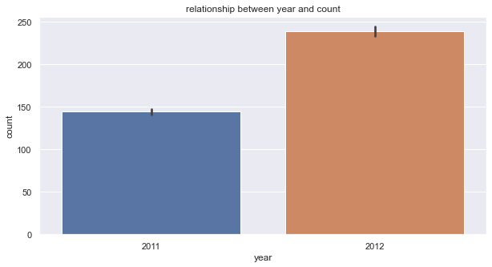

```python
plt.figure(figsize= (10, 5))
sns.barplot(data=train, x="year", y="count")
plt.title("relationship between year and count")
plt.show()
```

### the most year in which users rent bicycles is 2012 .

```python
train.var()
```

```
season            1.245845
holiday           0.027755
workingday        0.217304
weather           0.401751
temp             60.708872
atemp            71.818856
humidity        370.371306
windspeed        66.659670
casual         2496.049219
registered    22812.789514
count         32813.313153
dayofweek         4.018363
hour             47.828815
day              29.993238
month            11.863709
year              0.250019
dtype: float64
```

```python
train.info()
```

```
<class 'pandas.core.frame.DataFrame'>
RangeIndex: 10886 entries, 0 to 10885
Data columns (total 17 columns):
 #   Column      Non-Null Count  Dtype
---  ------      --------------  -----
 0   datetime    10886 non-null  datetime64[ns]
 1   season      10886 non-null  int64
 2   holiday     10886 non-null  int64
 3   workingday  10886 non-null  int64
 4   weather     10886 non-null  int64
 5   temp        10886 non-null  float64
 6   atemp       10886 non-null  float64
 7   humidity    10886 non-null  int64
 8   windspeed   10886 non-null  float64
 9   casual      10886 non-null  int64
 10  registered  10886 non-null  int64
 11  count       10886 non-null  int64
 12  dayofweek   10886 non-null  int64
 13  hour        10886 non-null  int64
 14  day         10886 non-null  int64
 15  month       10886 non-null  int64
 16  year        10886 non-null  int64
dtypes: datetime64[ns](1), float64(3), int64(13)
memory usage: 1.4 MB
```

```python
test.info()
```

```
<class 'pandas.core.frame.DataFrame'>
RangeIndex: 6493 entries, 0 to 6492
Data columns (total 14 columns):
 #   Column      Non-Null Count  Dtype
---  ------      --------------  -----
 0   datetime    6493 non-null   datetime64[ns]
 1   season      6493 non-null   int64
 2   holiday     6493 non-null   int64
 3   workingday  6493 non-null   int64
 4   weather     6493 non-null   int64
 5   temp        6493 non-null   float64
 6   atemp       6493 non-null   float64
 7   humidity    6493 non-null   int64
 8   windspeed   6493 non-null   float64
 9   dayofweek   6493 non-null   int64
 10  hour        6493 non-null   int64
 11  day         6493 non-null   int64
 12  month       6493 non-null   int64
 13  year        6493 non-null   int64
dtypes: datetime64[ns](1), float64(3), int64(10)
memory usage: 710.3 KB
```

### Feature Engineering

- add new features

```python
train['weather'] = train['weather'].map({1: 'clear',2:  'few clouds', 3: 'partly cloudy', 4: 'cloudy'})
train['season'] = train['season'].map({1 : 'spring', 2 : 'summer', 3 : 'fall', 4 : 'winter' })
#train['holiday'] = train['holiday'].map({0 : 'no', 1 : 'yes'})
#train['workingday'] = train['workingday'].map({0 : 'no', 1 : 'yes'})
test['weather'] = test['weather'].map({1: 'clear',2:  'few clouds', 3: 'partly cloudy', 4: 'cloudy'})
test['season'] = test['season'].map({1 : 'spring', 2 : 'summer', 3 : 'fall', 4 : 'winter' })
#test['holiday'] = test['holiday'].map({0 : 'no', 1 : 'yes'})
#test['workingday'] = test['workingday'].map({0 : 'no', 1 : 'yes'})
```

```python
train['holiday'].value_counts()
```

```
0    10575
1      311
Name: holiday, dtype: int64
```

```python
train['workingday'].value_counts()
```

```
1    7412
0    3474
Name: workingday, dtype: int64
```

```python
train.head()
```

|  | datetime | season | holiday | workingday | weather | temp | atemp | humidity | windspeed | casual | registered | count | dayofweek | hour | day | month | year |
| --- | --- | --- | --- | --- | --- | --- | --- | --- | --- | --- | --- | --- | --- | --- | --- | --- | --- |
| 0 | 2011-01-01 00:00:00 | spring | 0 | 0 | clear | 9.84 | 14.395 | 81 | 0.0 | 3 | 13 | 16 | 5 | 0 | 1 | 1 | 2011 |
| 1 | 2011-01-01 01:00:00 | spring | 0 | 0 | clear | 9.02 | 13.635 | 80 | 0.0 | 8 | 32 | 40 | 5 | 1 | 1 | 1 | 2011 |
| 2 | 2011-01-01 02:00:00 | spring | 0 | 0 | clear | 9.02 | 13.635 | 80 | 0.0 | 5 | 27 | 32 | 5 | 2 | 1 | 1 | 2011 |
| 3 | 2011-01-01 03:00:00 | spring | 0 | 0 | clear | 9.84 | 14.395 | 75 | 0.0 | 3 | 10 | 13 | 5 | 3 | 1 | 1 | 2011 |
| 4 | 2011-01-01 04:00:00 | spring | 0 | 0 | clear | 9.84 | 14.395 | 75 | 0.0 | 0 | 1 | 1 | 5 | 4 | 1 | 1 | 2011 |

```python
test.head()
```

|  | datetime | season | holiday | workingday | weather | temp | atemp | humidity | windspeed | dayofweek | hour | day | month | year |
| --- | --- | --- | --- | --- | --- | --- | --- | --- | --- | --- | --- | --- | --- | --- |
| 0 | 2011-01-20 00:00:00 | spring | 0 | 1 | clear | 10.66 | 11.365 | 56 | 26.0027 | 3 | 0 | 20 | 1 | 2011 |
| 1 | 2011-01-20 01:00:00 | spring | 0 | 1 | clear | 10.66 | 13.635 | 56 | 0.0000 | 3 | 1 | 20 | 1 | 2011 |
| 2 | 2011-01-20 02:00:00 | spring | 0 | 1 | clear | 10.66 | 13.635 | 56 | 0.0000 | 3 | 2 | 20 | 1 | 2011 |
| 3 | 2011-01-20 03:00:00 | spring | 0 | 1 | clear | 10.66 | 12.880 | 56 | 11.0014 | 3 | 3 | 20 | 1 | 2011 |
| 4 | 2011-01-20 04:00:00 | spring | 0 | 1 | clear | 10.66 | 12.880 | 56 | 11.0014 | 3 | 4 | 20 | 1 | 2011 |

```python
# Feature that categorizes hours
bins = [-np.inf, 0, 11, 12, 17, np.inf]
labels = ['MIDNIGHT', 'MORNING', 'MIDDAY', 'AFTERNOON', 'EVENING']
train['times of the day'] = pd.cut(train['hour'], bins= bins, labels= labels)
train['times of the day'] = train['times of the day'].str.lower()
```

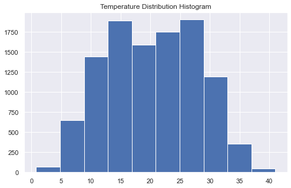

```python
train['temp'].hist(figsize= (8, 5));
plt.title('Temperature Distribution Histogram')
plt.show()
```

```python
#Feature that categorizes hot/cold/mild temps from temp

bins = [-np.inf, 20, 30, np.inf]
labels = ['cold', 'mild', 'hot']
train['temp of the day'] = pd.cut(train['temp'], bins= bins, labels= labels)
train['temp of the day'].value_counts()
```

```
cold    5308
mild    4334
hot     1244
Name: temp of the day, dtype: int64
```

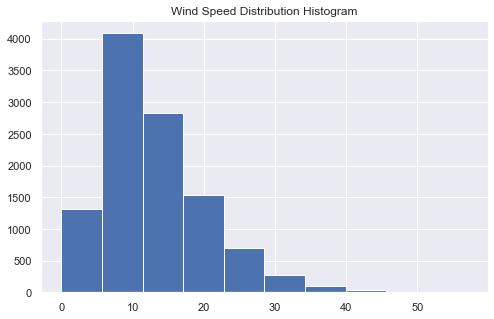

```python
train['windspeed'].hist(figsize= (8, 5));
plt.title('Wind Speed Distribution Histogram')
plt.show()
```

```python
#Feature that categories Calm, Moderate, Strong.
bins = [-np.inf, 20, 38, np.inf]
labels = ['calm', 'moderate', 'strong']
train['windspeed of the day'] = pd.cut(train['windspeed'], bins= bins, labels= labels)
train['windspeed of the day'].value_counts()
```

```
calm        9391
moderate    1428
strong        67
Name: windspeed of the day, dtype: int64
```

```python
# Feature that categorizes hours
bins = [-np.inf, 0, 11, 12, 17, np.inf]
labels = ['MIDNIGHT', 'MORNING', 'MIDDAY', 'AFTERNOON', 'EVENING']
test['times of the day'] = pd.cut(train['hour'], bins= bins, labels= labels)
test['times of the day'] = test['times of the day'].str.lower()
```

```python
#Feature that categorizes hot/cold/mild temps from temp

bins = [-np.inf, 20, 30, np.inf]
labels = ['cold', 'mild', 'hot']
test['temp of the day'] = pd.cut(test['temp'], bins= bins, labels= labels)
test['temp of the day'].value_counts()
```

```
cold    3021
mild    2601
hot      871
Name: temp of the day, dtype: int64
```

```python
#Feature that categories Calm, Moderate, Strong.
bins = [-np.inf, 20, 38, np.inf]
labels = ['calm', 'moderate', 'strong']
test['windspeed of the day'] = pd.cut(test['windspeed'], bins= bins, labels= labels)
test['windspeed of the day'].value_counts()
```

```
calm        5585
moderate     868
strong        40
Name: windspeed of the day, dtype: int64
```

## Make category types for these so models know they are not just numbers

```python
train.columns
```

```
Index(['datetime', 'season', 'holiday', 'workingday', 'weather', 'temp',
       'atemp', 'humidity', 'windspeed', 'casual', 'registered', 'count',
       'dayofweek', 'hour', 'day', 'month', 'year', 'times of the day',
       'temp of the day', 'windspeed of the day'],
      dtype='object')
```

```python
train.head()
```

|  | datetime | season | holiday | workingday | weather | temp | atemp | humidity | windspeed | casual | registered | count | dayofweek | hour | day | month | year | times of the day | temp of the day | windspeed of the day |
| --- | --- | --- | --- | --- | --- | --- | --- | --- | --- | --- | --- | --- | --- | --- | --- | --- | --- | --- | --- | --- |
| 0 | 2011-01-01 00:00:00 | spring | 0 | 0 | clear | 9.84 | 14.395 | 81 | 0.0 | 3 | 13 | 16 | 5 | 0 | 1 | 1 | 2011 | midnight | cold | calm |
| 1 | 2011-01-01 01:00:00 | spring | 0 | 0 | clear | 9.02 | 13.635 | 80 | 0.0 | 8 | 32 | 40 | 5 | 1 | 1 | 1 | 2011 | morning | cold | calm |
| 2 | 2011-01-01 02:00:00 | spring | 0 | 0 | clear | 9.02 | 13.635 | 80 | 0.0 | 5 | 27 | 32 | 5 | 2 | 1 | 1 | 2011 | morning | cold | calm |
| 3 | 2011-01-01 03:00:00 | spring | 0 | 0 | clear | 9.84 | 14.395 | 75 | 0.0 | 3 | 10 | 13 | 5 | 3 | 1 | 1 | 2011 | morning | cold | calm |
| 4 | 2011-01-01 04:00:00 | spring | 0 | 0 | clear | 9.84 | 14.395 | 75 | 0.0 | 0 | 1 | 1 | 5 | 4 | 1 | 1 | 2011 | morning | cold | calm |

```python
train["season"] =train["season"].astype("category")
train["weather"] = train["weather"].astype("category")
train["holiday"] = train["holiday"].astype("category")
train["workingday"] = train["workingday"].astype("category")
train["times of the day"] = train["times of the day"].astype("category")
train["temp of the day"] = train["temp of the day"].astype("category")
train["windspeed of the day"] = train["windspeed of the day"].astype("category")
train['month'] = train['month'].astype("category")
train['year'] = train['year'].astype("category")
train['hour'] = train['hour'].astype("str")
train['dayofweek'] = train['dayofweek'].astype("str")
test["season"] = test["season"].astype("category")
test["weather"] = test["weather"].astype("category")
test["holiday"] = test["holiday"].astype("category")
test["workingday"] = test["workingday"].astype("category")
test["times of the day"] = test["times of the day"].astype("category")
test["temp of the day"] = test["temp of the day"].astype("category")
test["windspeed of the day"] = test["windspeed of the day"].astype("category")
test['month'] = test['month'].astype("category")
test['year'] = test['year'].astype("category")
test['hour'] = test['hour'].astype("str")
test['dayofweek'] = test['dayofweek'].astype("str")
```

```python
# View are new feature
pd.set_option('display.max_columns', 500)
train.head()
```

|  | datetime | season | holiday | workingday | weather | temp | atemp | humidity | windspeed | casual | registered | count | dayofweek | hour | day | month | year | times of the day | temp of the day | windspeed of the day |
| --- | --- | --- | --- | --- | --- | --- | --- | --- | --- | --- | --- | --- | --- | --- | --- | --- | --- | --- | --- | --- |
| 0 | 2011-01-01 00:00:00 | spring | 0 | 0 | clear | 9.84 | 14.395 | 81 | 0.0 | 3 | 13 | 16 | 5 | 0 | 1 | 1 | 2011 | midnight | cold | calm |
| 1 | 2011-01-01 01:00:00 | spring | 0 | 0 | clear | 9.02 | 13.635 | 80 | 0.0 | 8 | 32 | 40 | 5 | 1 | 1 | 1 | 2011 | morning | cold | calm |
| 2 | 2011-01-01 02:00:00 | spring | 0 | 0 | clear | 9.02 | 13.635 | 80 | 0.0 | 5 | 27 | 32 | 5 | 2 | 1 | 1 | 2011 | morning | cold | calm |
| 3 | 2011-01-01 03:00:00 | spring | 0 | 0 | clear | 9.84 | 14.395 | 75 | 0.0 | 3 | 10 | 13 | 5 | 3 | 1 | 1 | 2011 | morning | cold | calm |
| 4 | 2011-01-01 04:00:00 | spring | 0 | 0 | clear | 9.84 | 14.395 | 75 | 0.0 | 0 | 1 | 1 | 5 | 4 | 1 | 1 | 2011 | morning | cold | calm |

```python
train.info()
```

```
<class 'pandas.core.frame.DataFrame'>
RangeIndex: 10886 entries, 0 to 10885
Data columns (total 20 columns):
 #   Column                Non-Null Count  Dtype
---  ------                --------------  -----
 0   datetime              10886 non-null  datetime64[ns]
 1   season                10886 non-null  category
 2   holiday               10886 non-null  category
 3   workingday            10886 non-null  category
 4   weather               10886 non-null  category
 5   temp                  10886 non-null  float64
 6   atemp                 10886 non-null  float64
 7   humidity              10886 non-null  int64
 8   windspeed             10886 non-null  float64
 9   casual                10886 non-null  int64
 10  registered            10886 non-null  int64
 11  count                 10886 non-null  int64
 12  dayofweek             10886 non-null  object
 13  hour                  10886 non-null  object
 14  day                   10886 non-null  int64
 15  month                 10886 non-null  category
 16  year                  10886 non-null  category
 17  times of the day      10886 non-null  category
 18  temp of the day       10886 non-null  category
 19  windspeed of the day  10886 non-null  category
dtypes: category(9), datetime64[ns](1), float64(3), int64(5), object(2)
memory usage: 1.0+ MB
```

```python
test.info()
```

```
<class 'pandas.core.frame.DataFrame'>
RangeIndex: 6493 entries, 0 to 6492
Data columns (total 17 columns):
 #   Column                Non-Null Count  Dtype
---  ------                --------------  -----
 0   datetime              6493 non-null   datetime64[ns]
 1   season                6493 non-null   category
 2   holiday               6493 non-null   category
 3   workingday            6493 non-null   category
 4   weather               6493 non-null   category
 5   temp                  6493 non-null   float64
 6   atemp                 6493 non-null   float64
 7   humidity              6493 non-null   int64
 8   windspeed             6493 non-null   float64
 9   dayofweek             6493 non-null   object
 10  hour                  6493 non-null   object
 11  day                   6493 non-null   int64
 12  month                 6493 non-null   category
 13  year                  6493 non-null   category
 14  times of the day      6493 non-null   category
 15  temp of the day       6493 non-null   category
 16  windspeed of the day  6493 non-null   category
dtypes: category(9), datetime64[ns](1), float64(3), int64(2), object(2)
memory usage: 464.6+ KB
```

```python
train.isnull().sum()
```

```
datetime                0
season                  0
holiday                 0
workingday              0
weather                 0
temp                    0
atemp                   0
humidity                0
windspeed               0
casual                  0
registered              0
count                   0
dayofweek               0
hour                    0
day                     0
month                   0
year                    0
times of the day        0
temp of the day         0
windspeed of the day    0
dtype: int64
```

```python
test.isnull().sum()
```

```
datetime                0
season                  0
holiday                 0
workingday              0
weather                 0
temp                    0
atemp                   0
humidity                0
windspeed               0
dayofweek               0
hour                    0
day                     0
month                   0
year                    0
times of the day        0
temp of the day         0
windspeed of the day    0
dtype: int64
```

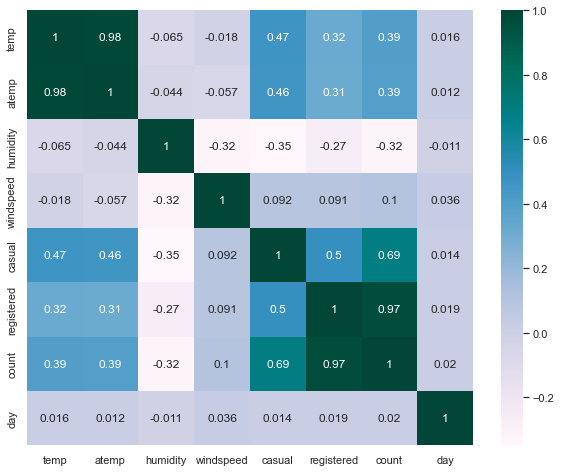

```python
plt.figure(figsize= (10, 8))
sns.heatmap(train.corr(), annot = True, cmap = 'PuBuGn')
plt.show()
```

```python
train.describe().T.style.background_gradient(cmap='PuBuGn')
```

|  | count | mean | std | min | 25% | 50% | 75% | max |
| --- | --- | --- | --- | --- | --- | --- | --- | --- |
| temp | 10886.000000 | 20.230860 | 7.791590 | 0.820000 | 13.940000 | 20.500000 | 26.240000 | 41.000000 |
| atemp | 10886.000000 | 23.655084 | 8.474601 | 0.760000 | 16.665000 | 24.240000 | 31.060000 | 45.455000 |
| humidity | 10886.000000 | 61.886460 | 19.245033 | 0.000000 | 47.000000 | 62.000000 | 77.000000 | 100.000000 |
| windspeed | 10886.000000 | 12.799395 | 8.164537 | 0.000000 | 7.001500 | 12.998000 | 16.997900 | 56.996900 |
| casual | 10886.000000 | 36.021955 | 49.960477 | 0.000000 | 4.000000 | 17.000000 | 49.000000 | 367.000000 |
| registered | 10886.000000 | 155.552177 | 151.039033 | 0.000000 | 36.000000 | 118.000000 | 222.000000 | 886.000000 |
| count | 10886.000000 | 191.574132 | 181.144454 | 1.000000 | 42.000000 | 145.000000 | 284.000000 | 977.000000 |
| day | 10886.000000 | 9.992559 | 5.476608 | 1.000000 | 5.000000 | 10.000000 | 15.000000 | 19.000000 |

```python
train.sample(10)
```

|  | datetime | season | holiday | workingday | weather | temp | atemp | humidity | windspeed | casual | registered | count | dayofweek | hour | day | month | year | times of the day | temp of the day | windspeed of the day |
| --- | --- | --- | --- | --- | --- | --- | --- | --- | --- | --- | --- | --- | --- | --- | --- | --- | --- | --- | --- | --- |
| 2568 | 2011-06-14 22:00:00 | summer | 0 | 1 | clear | 23.78 | 27.275 | 60 | 15.0013 | 29 | 159 | 188 | 1 | 22 | 14 | 6 | 2011 | evening | mild | calm |
| 3861 | 2011-09-11 21:00:00 | fall | 0 | 0 | clear | 26.24 | 30.305 | 69 | 0.0000 | 45 | 114 | 159 | 6 | 21 | 11 | 9 | 2011 | evening | mild | calm |
| 10345 | 2012-11-16 11:00:00 | winter | 0 | 1 | clear | 15.58 | 19.695 | 43 | 15.0013 | 33 | 185 | 218 | 4 | 11 | 16 | 11 | 2012 | morning | cold | calm |
| 4538 | 2011-11-02 04:00:00 | winter | 0 | 1 | clear | 12.30 | 16.665 | 87 | 0.0000 | 0 | 4 | 4 | 2 | 4 | 2 | 11 | 2011 | morning | cold | calm |
| 4258 | 2011-10-09 11:00:00 | winter | 0 | 0 | clear | 25.42 | 31.060 | 53 | 6.0032 | 189 | 234 | 423 | 6 | 11 | 9 | 10 | 2011 | morning | mild | calm |
| 3087 | 2011-07-17 13:00:00 | fall | 0 | 0 | clear | 32.80 | 37.120 | 49 | 19.9995 | 200 | 272 | 472 | 6 | 13 | 17 | 7 | 2011 | afternoon | hot | calm |
| 3764 | 2011-09-07 19:00:00 | fall | 0 | 1 | few clouds | 26.24 | 28.790 | 89 | 0.0000 | 14 | 212 | 226 | 2 | 19 | 7 | 9 | 2011 | evening | mild | calm |
| 2959 | 2011-07-12 05:00:00 | fall | 0 | 1 | clear | 28.70 | 33.335 | 79 | 6.0032 | 4 | 21 | 25 | 1 | 5 | 12 | 7 | 2011 | morning | mild | calm |
| 3156 | 2011-08-01 10:00:00 | fall | 0 | 1 | clear | 35.26 | 37.880 | 36 | 11.0014 | 27 | 70 | 97 | 0 | 10 | 1 | 8 | 2011 | morning | hot | calm |
| 9145 | 2012-09-04 10:00:00 | fall | 0 | 1 | few clouds | 29.52 | 34.850 | 74 | 16.9979 | 42 | 130 | 172 | 1 | 10 | 4 | 9 | 2012 | morning | mild | calm |

```python
test.sample(10)
```

|  | datetime | season | holiday | workingday | weather | temp | atemp | humidity | windspeed | dayofweek | hour | day | month | year | times of the day | temp of the day | windspeed of the day |
| --- | --- | --- | --- | --- | --- | --- | --- | --- | --- | --- | --- | --- | --- | --- | --- | --- | --- |
| 6158 | 2012-11-28 22:00:00 | winter | 0 | 1 | clear | 11.48 | 13.635 | 45 | 11.0014 | 2 | 22 | 28 | 11 | 2012 | evening | cold | calm |
| 2308 | 2011-09-27 17:00:00 | winter | 0 | 1 | few clouds | 27.06 | 29.545 | 89 | 12.9980 | 1 | 17 | 27 | 9 | 2011 | morning | mild | calm |
| 4736 | 2012-06-26 04:00:00 | fall | 0 | 1 | clear | 22.14 | 25.760 | 45 | 19.9995 | 1 | 4 | 26 | 6 | 2012 | morning | mild | calm |
| 1587 | 2011-07-21 03:00:00 | fall | 0 | 1 | few clouds | 30.34 | 35.605 | 79 | 8.9981 | 3 | 3 | 21 | 7 | 2011 | morning | hot | calm |
| 5820 | 2012-10-25 08:00:00 | winter | 0 | 1 | few clouds | 21.32 | 25.000 | 83 | 11.0014 | 3 | 8 | 25 | 10 | 2012 | afternoon | mild | calm |
| 568 | 2011-03-24 14:00:00 | summer | 0 | 1 | few clouds | 12.30 | 15.150 | 70 | 8.9981 | 3 | 14 | 24 | 3 | 2011 | evening | cold | calm |
| 4097 | 2012-04-22 13:00:00 | summer | 0 | 0 | partly cloudy | 15.58 | 19.695 | 82 | 23.9994 | 6 | 13 | 22 | 4 | 2012 | evening | cold | moderate |
| 1897 | 2011-08-22 01:00:00 | fall | 0 | 1 | clear | 27.88 | 31.820 | 79 | 6.0032 | 0 | 1 | 22 | 8 | 2011 | evening | mild | calm |
| 4000 | 2012-03-30 12:00:00 | summer | 0 | 1 | few clouds | 15.58 | 19.695 | 54 | 0.0000 | 4 | 12 | 30 | 3 | 2012 | afternoon | cold | calm |
| 4832 | 2012-06-30 04:00:00 | fall | 0 | 0 | few clouds | 25.42 | 27.275 | 94 | 0.0000 | 5 | 4 | 30 | 6 | 2012 | morning | mild | calm |

```python
def describe_cont_feature(feature):
    print('\n*** Results for {} ***'.format(feature))
    print(train.groupby('temp of the day')[feature].describe())

describe_cont_feature('count')
```

```
*** Results for count ***
                  count        mean         std  min    25%    50%    75%  \
temp of the day
cold             5308.0  132.135268  138.794661  1.0   24.0   89.0  194.0
mild             4334.0  223.411398  195.357875  1.0   58.0  181.0  328.0
hot              1244.0  334.274116  181.823864  4.0  198.0  303.0  441.0

                   max
temp of the day
cold             837.0
mild             977.0
hot              897.0
```

```python
def describe_cont_feature(feature):
    print('\n*** Results for {} ***'.format(feature))
    print(train.groupby('windspeed of the day')[feature].describe())

describe_cont_feature('count')
```

```
*** Results for count ***
                       count        mean         std  min   25%    50%  \
windspeed of the day
calm                  9391.0  189.033436  181.506649  1.0  38.0  141.0
moderate              1428.0  209.392157  179.130130  1.0  71.0  164.5
strong                  67.0  167.925373  149.851271  1.0  55.0  140.0

                         75%    max
windspeed of the day
calm                  282.00  977.0
moderate              302.25  890.0
strong                219.00  755.0
```

```python
def describe_cont_feature(feature):
    print('\n*** Results for {} ***'.format(feature))
    print(train.groupby('times of the day')[feature].describe())

describe_cont_feature('count')
```

```
*** Results for count ***
                   count        mean         std  min    25%    50%     75%  \
times of the day
afternoon         2280.0  308.133333  185.142294  7.0  170.0  271.0  412.25
evening           2736.0  228.518640  173.859618  4.0   99.0  180.0  308.00
midday             456.0  256.508772  143.881880  3.0  157.0  234.5  332.00
midnight           455.0   55.138462   43.620012  2.0   24.0   41.0   74.50
morning           4959.0  124.147812  154.567065  1.0   11.0   56.0  187.50

                    max
times of the day
afternoon         970.0
evening           977.0
midday            757.0
midnight          283.0
morning           839.0
```

```python
train.columns
```

```
Index(['datetime', 'season', 'holiday', 'workingday', 'weather', 'temp',
       'atemp', 'humidity', 'windspeed', 'casual', 'registered', 'count',
       'dayofweek', 'hour', 'day', 'month', 'year', 'times of the day',
       'temp of the day', 'windspeed of the day'],
      dtype='object')
```

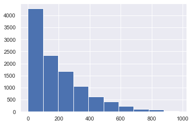

```python
train['count'].hist()
plt.show()
```

```python
#Feature that categories "low" "medium"  "above average" "high".
bins = [-np.inf, 400,  np.inf]
labels = ["normal number", "abnormal number"]
train['count_category'] = pd.cut(train['count'], bins= bins, labels= labels)
train['count_category'].value_counts()
```

```
normal number      9443
abnormal number    1443
Name: count_category, dtype: int64
```

```python
pd.crosstab(train['count_category'], train['windspeed of the day']).style.background_gradient(cmap='PuBuGn')
```

| windspeed of the day count_category | calm | moderate | strong |
| --- | --- | --- | --- |
| normal number | 8156 | 1223 | 64 |
| abnormal number | 1235 | 205 | 3 |

```python
pd.crosstab(train['count_category'], train['temp of the day']).style.background_gradient(cmap='PuBuGn')
```

| temp of the day count_category | cold | mild | hot |
| --- | --- | --- | --- |
| normal number | 4992 | 3595 | 856 |
| abnormal number | 316 | 739 | 388 |

```python
pd.crosstab(train['count_category'], train['times of the day']).style.background_gradient(cmap='PuBuGn')
```

| times of the day count_category | afternoon | evening | midday | midnight | morning |
| --- | --- | --- | --- | --- | --- |
| normal number | 1675 | 2318 | 389 | 455 | 4606 |
| abnormal number | 605 | 418 | 67 | 0 | 353 |

```python
def describe_cont_feature(feature):
    print('\n*** Results for {} ***'.format(feature))
    print(train.groupby('count_category')[feature].describe())

for col in train.columns:
    #if (train[col].dtype == 'int64' or train[col].dtype == 'float64 '):
    describe_cont_feature(col)
```

```
*** Results for datetime ***
                count unique                 top freq               first  \
count_category
normal number    9443   9443 2011-01-01 00:00:00    1 2011-01-01 00:00:00
abnormal number  1443   1443 2011-04-11 17:00:00    1 2011-04-11 17:00:00

                               last
count_category
normal number   2012-12-19 23:00:00
abnormal number 2012-12-19 18:00:00

*** Results for season ***
                count unique     top  freq
count_category
normal number    9443      4  spring  2566
abnormal number  1443      4    fall   508

*** Results for holiday ***
                 count  unique  top  freq
count_category
normal number     9443       2    0  9178
abnormal number   1443       2    0  1397

*** Results for workingday ***
                 count  unique  top  freq
count_category
normal number     9443       2    1  6464
abnormal number   1443       2    1   948

*** Results for weather ***
                count unique    top  freq
count_category
normal number    9443      4  clear  6094
abnormal number  1443      3  clear  1098

*** Results for temp ***
                  count       mean       std   min    25%    50%    75%    max
count_category
normal number    9443.0  19.463603  7.688941  0.82  13.12  18.86  25.42  41.00
abnormal number  1443.0  25.251795  6.486419  4.10  20.50  26.24  30.34  37.72
```

[output cut: 95 more lines]

```
count_category
normal number    9443      3  cold  4992
abnormal number  1443      3  mild   739

*** Results for windspeed of the day ***
                count unique   top  freq
count_category
normal number    9443      3  calm  8156
abnormal number  1443      3  calm  1235

*** Results for count_category ***
                count unique              top  freq
count_category
normal number    9443      1    normal number  9443
abnormal number  1443      1  abnormal number  1443
```

```python
train[train["count_category"] == 'abnormal number'].head()
```

|  | datetime | season | holiday | workingday | weather | temp | atemp | humidity | windspeed | casual | registered | count | dayofweek | hour | day | month | year | times of the day | temp of the day | windspeed of the day | count_category |
| --- | --- | --- | --- | --- | --- | --- | --- | --- | --- | --- | --- | --- | --- | --- | --- | --- | --- | --- | --- | --- | --- |
| 1579 | 2011-04-11 17:00:00 | summer | 0 | 1 | clear | 30.34 | 33.335 | 48 | 35.0008 | 100 | 352 | 452 | 0 | 17 | 11 | 4 | 2011 | afternoon | hot | moderate | abnormal number |
| 1747 | 2011-04-18 17:00:00 | summer | 0 | 1 | clear | 23.78 | 27.275 | 49 | 19.0012 | 66 | 362 | 428 | 0 | 17 | 18 | 4 | 2011 | afternoon | mild | calm | abnormal number |
| 1771 | 2011-04-19 17:00:00 | summer | 0 | 1 | clear | 22.96 | 26.515 | 60 | 7.0015 | 39 | 372 | 411 | 1 | 17 | 19 | 4 | 2011 | afternoon | mild | calm | abnormal number |
| 1772 | 2011-04-19 18:00:00 | summer | 0 | 1 | few clouds | 22.14 | 25.760 | 64 | 8.9981 | 44 | 377 | 421 | 1 | 18 | 19 | 4 | 2011 | evening | mild | calm | abnormal number |
| 1819 | 2011-05-02 17:00:00 | summer | 0 | 1 | clear | 27.06 | 31.060 | 65 | 12.9980 | 65 | 472 | 537 | 0 | 17 | 2 | 5 | 2011 | afternoon | mild | calm | abnormal number |

```python
train[train["count_category"] == 'normal number'].head()
```

|  | datetime | season | holiday | workingday | weather | temp | atemp | humidity | windspeed | casual | registered | count | dayofweek | hour | day | month | year | times of the day | temp of the day | windspeed of the day | count_category |
| --- | --- | --- | --- | --- | --- | --- | --- | --- | --- | --- | --- | --- | --- | --- | --- | --- | --- | --- | --- | --- | --- |
| 0 | 2011-01-01 00:00:00 | spring | 0 | 0 | clear | 9.84 | 14.395 | 81 | 0.0 | 3 | 13 | 16 | 5 | 0 | 1 | 1 | 2011 | midnight | cold | calm | normal number |
| 1 | 2011-01-01 01:00:00 | spring | 0 | 0 | clear | 9.02 | 13.635 | 80 | 0.0 | 8 | 32 | 40 | 5 | 1 | 1 | 1 | 2011 | morning | cold | calm | normal number |
| 2 | 2011-01-01 02:00:00 | spring | 0 | 0 | clear | 9.02 | 13.635 | 80 | 0.0 | 5 | 27 | 32 | 5 | 2 | 1 | 1 | 2011 | morning | cold | calm | normal number |
| 3 | 2011-01-01 03:00:00 | spring | 0 | 0 | clear | 9.84 | 14.395 | 75 | 0.0 | 3 | 10 | 13 | 5 | 3 | 1 | 1 | 2011 | morning | cold | calm | normal number |
| 4 | 2011-01-01 04:00:00 | spring | 0 | 0 | clear | 9.84 | 14.395 | 75 | 0.0 | 0 | 1 | 1 | 5 | 4 | 1 | 1 | 2011 | morning | cold | calm | normal number |

```python
train[train["count_category"] == 'normal number'].describe().style.background_gradient(cmap='PuBuGn')
```

|  | temp | atemp | humidity | windspeed | casual | registered | count | day |
| --- | --- | --- | --- | --- | --- | --- | --- | --- |
| count | 9443.000000 | 9443.000000 | 9443.000000 | 9443.000000 | 9443.000000 | 9443.000000 | 9443.000000 | 9443.000000 |
| mean | 19.463603 | 22.829653 | 63.297045 | 12.632834 | 25.363550 | 111.189453 | 136.553002 | 9.985492 |
| std | 7.688941 | 8.400155 | 19.143434 | 8.213963 | 32.171598 | 91.292051 | 112.433425 | 5.484366 |
| min | 0.820000 | 0.760000 | 0.000000 | 0.000000 | 0.000000 | 0.000000 | 1.000000 | 1.000000 |
| 25% | 13.120000 | 15.910000 | 49.000000 | 7.001500 | 3.000000 | 27.000000 | 32.000000 | 5.000000 |
| 50% | 18.860000 | 22.725000 | 64.000000 | 11.001400 | 12.000000 | 96.000000 | 116.000000 | 10.000000 |
| 75% | 25.420000 | 30.305000 | 79.000000 | 16.997900 | 36.000000 | 175.000000 | 219.000000 | 15.000000 |
| max | 41.000000 | 45.455000 | 100.000000 | 56.996900 | 240.000000 | 391.000000 | 400.000000 | 19.000000 |

```python
train[train["count_category"] == 'abnormal number'].describe().style.background_gradient(cmap='PuBuGn')
```

|  | temp | atemp | humidity | windspeed | casual | registered | count | day |
| --- | --- | --- | --- | --- | --- | --- | --- | --- |
| count | 1443.000000 | 1443.000000 | 1443.000000 | 1443.000000 | 1443.000000 | 1443.000000 | 1443.000000 | 1443.000000 |
| mean | 25.251795 | 29.056712 | 52.655579 | 13.889374 | 105.770617 | 445.862093 | 551.632710 | 10.038808 |
| std | 6.486419 | 6.814310 | 17.258856 | 7.748206 | 80.325962 | 142.848973 | 123.947170 | 5.427228 |
| min | 4.100000 | 6.060000 | 16.000000 | 0.000000 | 1.000000 | 173.000000 | 401.000000 | 1.000000 |
| 25% | 20.500000 | 24.240000 | 39.000000 | 8.998100 | 39.000000 | 342.000000 | 453.500000 | 5.000000 |
| 50% | 26.240000 | 31.060000 | 51.000000 | 12.998000 | 84.000000 | 417.000000 | 516.000000 | 10.000000 |
| 75% | 30.340000 | 34.090000 | 65.000000 | 19.001200 | 164.000000 | 532.000000 | 623.000000 | 15.000000 |
| max | 37.720000 | 42.425000 | 100.000000 | 43.998900 | 367.000000 | 886.000000 | 977.000000 | 19.000000 |

# What is the best weather condition in which users rent bicycles ?

```python
train['weather'].value_counts()
```

```
clear            7192
few clouds       2834
partly cloudy     859
cloudy              1
Name: weather, dtype: int64
```

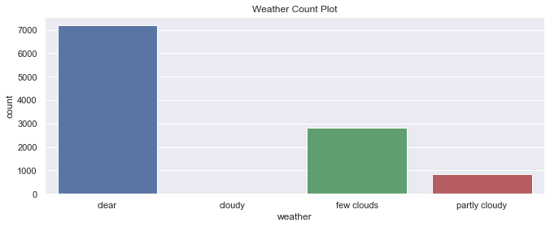

```python
plt.figure(figsize= (11, 4))
sns.countplot(data = train, x = 'weather')
plt.title('Weather Count Plot');
plt.show();
```

### the best weather condition in which users rent bicycles when the weather is clear .

# What is the best time of the day in which users rent bicycles ?

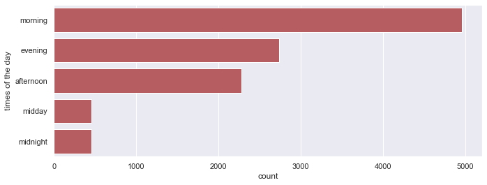

```python
plt.figure(figsize= (11, 4))
# The `color_palette()` returns the the current / default palette as a list of RGB tuples.
# Each tuple consists of three digits specifying the red, green, and blue channel values to specify a color.
# Choose the first tuple of RGB colors
base_color = sns.color_palette()[3]
# Dynamic-ordering the bars
# The order of the display of the bars can be computed with the following logic.
# Count the frequency of each unique value in the 'times of the day' column, and sort it in descending order
# Returns a Series
freq = train['times of the day'].value_counts()

# Get the indexes of the Series
gen_order = freq.index

# Plot the bar chart in the decreasing order of the frequency of the `times of the day`
sns.countplot(data=train, y='times of the day', color=base_color, order=gen_order);
```

### the best time of the day in which users rent bicycles is morning .

# what is the most day type (Holiday or Not) in which users rent bicycles ?

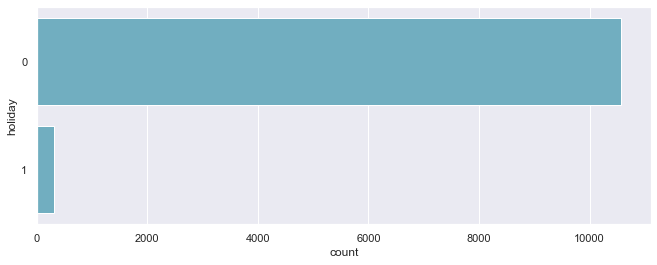

```python
plt.figure(figsize= (11, 4))
# The `color_palette()` returns the the current / default palette as a list of RGB tuples.
# Each tuple consists of three digits specifying the red, green, and blue channel values to specify a color.
# Choose the first tuple of RGB colors
base_color = sns.color_palette()[9]
# Dynamic-ordering the bars
# The order of the display of the bars can be computed with the following logic.
# Count the frequency of each unique value in the 'times of the day' column, and sort it in descending order
# Returns a Series
freq = train['holiday'].value_counts()

# Get the indexes of the Series
gen_order = freq.index

# Plot the bar chart in the decreasing order of the frequency of the `times of the day`
sns.countplot(data=train, y='holiday', color=base_color, order=gen_order);
```

### the most day type (Holiday or Working Day) in which users rent bicycles is Not Holiday(Working Day) .

# What is the best windspeed state of the day in which users rent bicycles ?

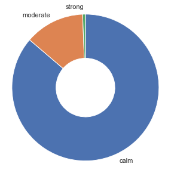

```python
plt.figure(figsize= (11, 5))
sorted_counts = train['windspeed of the day'].value_counts()

plt.pie(sorted_counts, labels = sorted_counts.index, startangle = 90,
        counterclock = False, wedgeprops = {'width' : 0.6});
plt.axis('square')
plt.show()
```

### the best windspeed of the day in which users rent bicycles when it is Calm.

# What is the best weather degree in which users rent bicycles ?

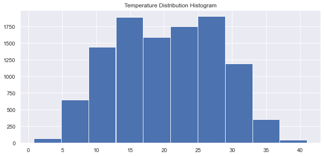

```python
plt.figure(figsize= (11, 5))
train['temp'].hist();
plt.title('Temperature Distribution Histogram')
plt.show()
```

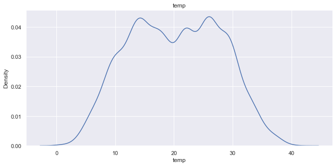

```python
plt.figure(figsize= (11, 5))
sns.distplot(train['temp'], bins = bins)
#train['windspeed'].hist(figsize= (11, 5));
plt.title('temp')
plt.show()
```

# from the distribution plot the best weather degree are (15 and 27.5)

```python
train.columns
```

```
Index(['datetime', 'season', 'holiday', 'workingday', 'weather', 'temp',
       'atemp', 'humidity', 'windspeed', 'casual', 'registered', 'count',
       'dayofweek', 'hour', 'day', 'month', 'year', 'times of the day',
       'temp of the day', 'windspeed of the day', 'count_category'],
      dtype='object')
```

# Analyze ( 'times of the day', 'temp of the day', 'windspeed of the day' ) When the count of Renting Bicycles is Normal or Abnormal.

- Times of the day when count of Renting Bicycles is normal and abnormal

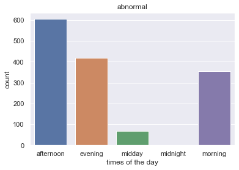

```python
sns.countplot(train[train["count_category"] == 'abnormal number']['times of the day'])
plt.title("abnormal")
plt.show()
```

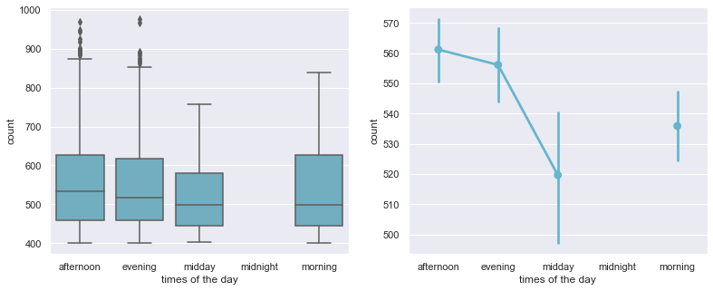

```python
base_color = sns.color_palette()[9]
plt.figure(figsize= (13, 5))
plt.subplot(1, 2, 1)
sns.boxplot(data=train[train["count_category"] == 'abnormal number'], x='times of the day', y='count', color=base_color)
plt.subplot(1, 2, 2)
sns.pointplot(data=train[train["count_category"] == 'abnormal number'], x='times of the day', y='count', color=base_color)
plt.show()
```

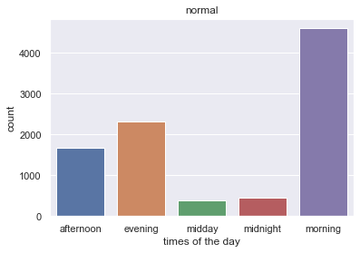

```python
sns.countplot(train[train["count_category"] == 'normal number']['times of the day'])
plt.title("normal")
plt.show()
```

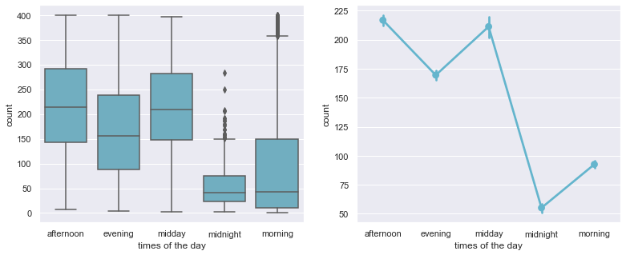

```python
base_color = sns.color_palette()[9]
plt.figure(figsize= (13, 5))
plt.subplot(1, 2, 1)
sns.boxplot(data=train[train["count_category"] == 'normal number'], x='times of the day', y='count', color=base_color)
plt.subplot(1, 2, 2)
sns.pointplot(data=train[train["count_category"] == 'normal number'], x='times of the day', y='count', color=base_color)
plt.show()
```

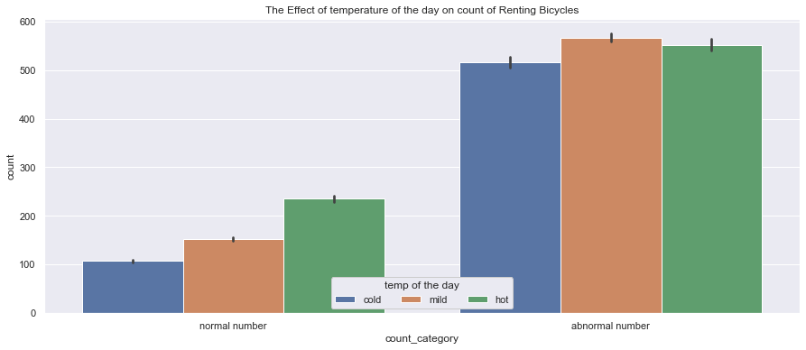

```python
plt.figure(figsize= (15, 6))
ax = sns.barplot(data = train, x = 'count_category', y = 'count', hue = 'temp of the day')
ax.legend(loc = 8, ncol = 3, framealpha = 1, title = 'temp of the day')
plt.title("The Effect of temperature of the day on count of Renting Bicycles")
plt.show()
```

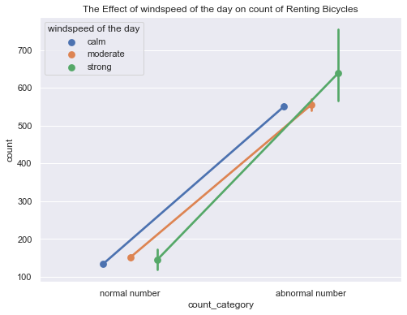

```python
plt.figure(figsize= (8, 6))
ax = sns.pointplot(data = train, x = 'count_category', y = 'count', hue = 'windspeed of the day',
                  dodge = 0.3, linestyles = "-")
#plt.xticks(rotation= 45);
plt.title("The Effect of windspeed of the day on count of Renting Bicycles")
plt.show()
```

Drop Columns Based on the above findings, the below columns can be dropped due to the following reasons:

No longer relevant: 'datetime'

Very high correlation with other features / label:

- 'season'
- 'casual'
- 'registered'
- 'atemp'

Has no correlation with 'count':

- 'day'

```python
train_trimmed = train.drop(["datetime", "season", "casual", "registered", "day", 'atemp', 'count_category'], axis=1)
test_trimmed = test.drop(["datetime", "season", "day", 'atemp'], axis=1)
display(train_trimmed.head())
```

|  | holiday | workingday | weather | temp | humidity | windspeed | count | dayofweek | hour | month | year | times of the day | temp of the day | windspeed of the day |
| --- | --- | --- | --- | --- | --- | --- | --- | --- | --- | --- | --- | --- | --- | --- |
| 0 | 0 | 0 | clear | 9.84 | 81 | 0.0 | 16 | 5 | 0 | 1 | 2011 | midnight | cold | calm |
| 1 | 0 | 0 | clear | 9.02 | 80 | 0.0 | 40 | 5 | 1 | 1 | 2011 | morning | cold | calm |
| 2 | 0 | 0 | clear | 9.02 | 80 | 0.0 | 32 | 5 | 2 | 1 | 2011 | morning | cold | calm |
| 3 | 0 | 0 | clear | 9.84 | 75 | 0.0 | 13 | 5 | 3 | 1 | 2011 | morning | cold | calm |
| 4 | 0 | 0 | clear | 9.84 | 75 | 0.0 | 1 | 5 | 4 | 1 | 2011 | morning | cold | calm |

```python
display(test_trimmed.head())
```

|  | holiday | workingday | weather | temp | humidity | windspeed | dayofweek | hour | month | year | times of the day | temp of the day | windspeed of the day |
| --- | --- | --- | --- | --- | --- | --- | --- | --- | --- | --- | --- | --- | --- |
| 0 | 0 | 1 | clear | 10.66 | 56 | 26.0027 | 3 | 0 | 1 | 2011 | midnight | cold | moderate |
| 1 | 0 | 1 | clear | 10.66 | 56 | 0.0000 | 3 | 1 | 1 | 2011 | morning | cold | calm |
| 2 | 0 | 1 | clear | 10.66 | 56 | 0.0000 | 3 | 2 | 1 | 2011 | morning | cold | calm |
| 3 | 0 | 1 | clear | 10.66 | 56 | 11.0014 | 3 | 3 | 1 | 2011 | morning | cold | calm |
| 4 | 0 | 1 | clear | 10.66 | 56 | 11.0014 | 3 | 4 | 1 | 2011 | morning | cold | calm |

```python
def detect_outlier(feature):
    outliers = []
    data = train_trimmed[feature]
    mean = np.mean(data)
    std =np.std(data)


    for y in data:
        z_score= (y - mean)/std
        if np.abs(z_score) > 3:
            outliers.append(y)
    print('\nOutlier caps for {}:'.format(feature))
    print('  --95p: {:.1f} / {} values exceed that'.format(data.quantile(.95),
                                                             len([i for i in data
                                                                  if i > data.quantile(.95)])))
    print('  --3sd: {:.1f} / {} values exceed that'.format(mean + 3*(std), len(outliers)))
    print('  --99p: {:.1f} / {} values exceed that'.format(data.quantile(.99),
                                                           len([i for i in data
                                                                if i > data.quantile(.99)])))
```

```python
# Determine what the upperbound should be for continuous features
for feat in ['temp', 'humidity', 'windspeed']:
    detect_outlier(feat)
```

```
Outlier caps for temp:
  --95p: 32.8 / 403 values exceed that
  --3sd: 43.6 / 0 values exceed that
  --99p: 36.1 / 94 values exceed that

Outlier caps for humidity:
  --95p: 93.0 / 474 values exceed that
  --3sd: 119.6 / 22 values exceed that
  --99p: 100.0 / 0 values exceed that

Outlier caps for windspeed:
  --95p: 28.0 / 427 values exceed that
  --3sd: 37.3 / 67 values exceed that
  --99p: 35.0 / 89 values exceed that
```

```python
train_trimmed.describe().T.style.background_gradient(cmap='PuBuGn')
```

|  | count | mean | std | min | 25% | 50% | 75% | max |
| --- | --- | --- | --- | --- | --- | --- | --- | --- |
| temp | 10886.000000 | 20.230860 | 7.791590 | 0.820000 | 13.940000 | 20.500000 | 26.240000 | 41.000000 |
| humidity | 10886.000000 | 61.886460 | 19.245033 | 0.000000 | 47.000000 | 62.000000 | 77.000000 | 100.000000 |
| windspeed | 10886.000000 | 12.799395 | 8.164537 | 0.000000 | 7.001500 | 12.998000 | 16.997900 | 56.996900 |
| count | 10886.000000 | 191.574132 | 181.144454 | 1.000000 | 42.000000 | 145.000000 | 284.000000 | 977.000000 |

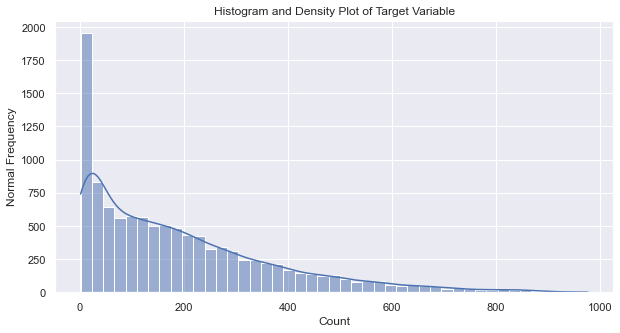

```python
fig, ax = plt.subplots(1,1, figsize=(10, 5))
ax.set_ylabel("Normal Frequency")
ax.set_xlabel("Count")
ax.set_title("Histogram and Density Plot of Target Variable")

sns.histplot(train_trimmed["count"], kde=True, ax=ax)
plt.show()
```

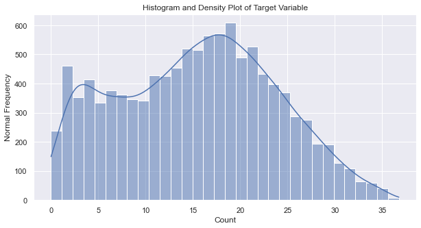

```python
# Transforming target variable using boxcox transformation
train_trimmed['count'] = boxcox(train_trimmed['count'], 0.4)

fig, ax = plt.subplots(1,1, figsize=(10, 5))
ax.set_ylabel("Normal Frequency")
ax.set_xlabel("Count")
ax.set_title("Histogram and Density Plot of Target Variable")

sns.histplot(train_trimmed['count'], kde=True, ax=ax)
plt.show()# Transforming target variable using boxcox transformation
```

```python
train_trimmed.head()
```

|  | holiday | workingday | weather | temp | humidity | windspeed | count | dayofweek | hour | month | year | times of the day | temp of the day | windspeed of the day |
| --- | --- | --- | --- | --- | --- | --- | --- | --- | --- | --- | --- | --- | --- | --- |
| 0 | 0 | 0 | clear | 9.84 | 81 | 0.0 | 5.078583 | 5 | 0 | 1 | 2011 | midnight | cold | calm |
| 1 | 0 | 0 | clear | 9.02 | 80 | 0.0 | 8.433621 | 5 | 1 | 1 | 2011 | morning | cold | calm |
| 2 | 0 | 0 | clear | 9.02 | 80 | 0.0 | 7.500000 | 5 | 2 | 1 | 2011 | morning | cold | calm |
| 3 | 0 | 0 | clear | 9.84 | 75 | 0.0 | 4.474569 | 5 | 3 | 1 | 2011 | morning | cold | calm |
| 4 | 0 | 0 | clear | 9.84 | 75 | 0.0 | 0.000000 | 5 | 4 | 1 | 2011 | morning | cold | calm |

```python
# we need to scall continuous Features
train_trimmed.describe().T.style.background_gradient(cmap='PuBuGn')
```

|  | count | mean | std | min | 25% | 50% | 75% | max |
| --- | --- | --- | --- | --- | --- | --- | --- | --- |
| temp | 10886.000000 | 20.230860 | 7.791590 | 0.820000 | 13.940000 | 20.500000 | 26.240000 | 41.000000 |
| humidity | 10886.000000 | 61.886460 | 19.245033 | 0.000000 | 47.000000 | 62.000000 | 77.000000 | 100.000000 |
| windspeed | 10886.000000 | 12.799395 | 8.164537 | 0.000000 | 7.001500 | 12.998000 | 16.997900 | 56.996900 |
| count | 10886.000000 | 15.371114 | 8.307670 | 0.000000 | 8.649098 | 15.801522 | 21.447895 | 36.755258 |

```python
# we need to scall continuous Features
train_trimmed.describe().T.style.background_gradient(cmap='PuBuGn')
```

|  | count | mean | std | min | 25% | 50% | 75% | max |
| --- | --- | --- | --- | --- | --- | --- | --- | --- |
| temp | 10886.000000 | 20.230860 | 7.791590 | 0.820000 | 13.940000 | 20.500000 | 26.240000 | 41.000000 |
| humidity | 10886.000000 | 61.886460 | 19.245033 | 0.000000 | 47.000000 | 62.000000 | 77.000000 | 100.000000 |
| windspeed | 10886.000000 | 12.799395 | 8.164537 | 0.000000 | 7.001500 | 12.998000 | 16.997900 | 56.996900 |
| count | 10886.000000 | 15.371114 | 8.307670 | 0.000000 | 8.649098 | 15.801522 | 21.447895 | 36.755258 |

```python
test_trimmed.describe().T.style.background_gradient(cmap='PuBuGn')
```

|  | count | mean | std | min | 25% | 50% | 75% | max |
| --- | --- | --- | --- | --- | --- | --- | --- | --- |
| temp | 6493.000000 | 20.620607 | 8.059583 | 0.820000 | 13.940000 | 21.320000 | 27.060000 | 40.180000 |
| humidity | 6493.000000 | 64.125212 | 19.293391 | 16.000000 | 49.000000 | 65.000000 | 81.000000 | 100.000000 |
| windspeed | 6493.000000 | 12.631157 | 8.250151 | 0.000000 | 7.001500 | 11.001400 | 16.997900 | 55.998600 |

```python
train_trimmed.var()
```

```
temp          60.708872
humidity     370.371306
windspeed     66.659670
count         69.017380
dtype: float64
```

```python
test_trimmed.var()
```

```
temp          64.956879
humidity     372.234936
windspeed     68.064994
dtype: float64
```

```python
train_trimmed.info()
```

```
<class 'pandas.core.frame.DataFrame'>
RangeIndex: 10886 entries, 0 to 10885
Data columns (total 14 columns):
 #   Column                Non-Null Count  Dtype
---  ------                --------------  -----
 0   holiday               10886 non-null  category
 1   workingday            10886 non-null  category
 2   weather               10886 non-null  category
 3   temp                  10886 non-null  float64
 4   humidity              10886 non-null  int64
 5   windspeed             10886 non-null  float64
 6   count                 10886 non-null  float64
 7   dayofweek             10886 non-null  object
 8   hour                  10886 non-null  object
 9   month                 10886 non-null  category
 10  year                  10886 non-null  category
 11  times of the day      10886 non-null  category
 12  temp of the day       10886 non-null  category
 13  windspeed of the day  10886 non-null  category
dtypes: category(8), float64(3), int64(1), object(2)
memory usage: 596.9+ KB
```

```python
# Get the dummies columns for categorical columns.

cat_cols = train_trimmed.select_dtypes(include=['category']).columns.tolist()
print(cat_cols)
```

```
['holiday', 'workingday', 'weather', 'month', 'year', 'times of the day', 'temp of the day', 'windspeed of the day']
```

```python
train_trimmed_dummies = pd.get_dummies(train_trimmed, drop_first= True,columns = cat_cols)
test_trimmed_dummies = pd.get_dummies(test_trimmed, drop_first= True,columns = cat_cols)
train_trimmed_dummies.columns
```

```
Index(['temp', 'humidity', 'windspeed', 'count', 'dayofweek', 'hour',
       'holiday_1', 'workingday_1', 'weather_cloudy', 'weather_few clouds',
       'weather_partly cloudy', 'month_2', 'month_3', 'month_4', 'month_5',
       'month_6', 'month_7', 'month_8', 'month_9', 'month_10', 'month_11',
       'month_12', 'year_2012', 'times of the day_evening',
       'times of the day_midday', 'times of the day_midnight',
       'times of the day_morning', 'temp of the day_mild',
       'temp of the day_hot', 'windspeed of the day_moderate',
       'windspeed of the day_strong'],
      dtype='object')
```

```python
train_trimmed_dummies.head()
```

|  | temp | humidity | windspeed | count | dayofweek | hour | holiday_1 | workingday_1 | weather_cloudy | weather_few clouds | weather_partly cloudy | month_2 | month_3 | month_4 | month_5 | month_6 | month_7 | month_8 | month_9 | month_10 | month_11 | month_12 | year_2012 | times of the day_evening | times of the day_midday | times of the day_midnight | times of the day_morning | temp of the day_mild | temp of the day_hot | … |
| --- | --- | --- | --- | --- | --- | --- | --- | --- | --- | --- | --- | --- | --- | --- | --- | --- | --- | --- | --- | --- | --- | --- | --- | --- | --- | --- | --- | --- | --- | --- |
| 0 | 9.84 | 81 | 0.0 | 5.078583 | 5 | 0 | 0 | 0 | 0 | 0 | 0 | 0 | 0 | 0 | 0 | 0 | 0 | 0 | 0 | 0 | 0 | 0 | 0 | 0 | 0 | 1 | 0 | 0 | 0 | … |
| 1 | 9.02 | 80 | 0.0 | 8.433621 | 5 | 1 | 0 | 0 | 0 | 0 | 0 | 0 | 0 | 0 | 0 | 0 | 0 | 0 | 0 | 0 | 0 | 0 | 0 | 0 | 0 | 0 | 1 | 0 | 0 | … |
| 2 | 9.02 | 80 | 0.0 | 7.500000 | 5 | 2 | 0 | 0 | 0 | 0 | 0 | 0 | 0 | 0 | 0 | 0 | 0 | 0 | 0 | 0 | 0 | 0 | 0 | 0 | 0 | 0 | 1 | 0 | 0 | … |
| 3 | 9.84 | 75 | 0.0 | 4.474569 | 5 | 3 | 0 | 0 | 0 | 0 | 0 | 0 | 0 | 0 | 0 | 0 | 0 | 0 | 0 | 0 | 0 | 0 | 0 | 0 | 0 | 0 | 1 | 0 | 0 | … |
| 4 | 9.84 | 75 | 0.0 | 0.000000 | 5 | 4 | 0 | 0 | 0 | 0 | 0 | 0 | 0 | 0 | 0 | 0 | 0 | 0 | 0 | 0 | 0 | 0 | 0 | 0 | 0 | 0 | 1 | 0 | 0 | … |

```python
test_trimmed_dummies.head()
```

|  | temp | humidity | windspeed | dayofweek | hour | holiday_1 | workingday_1 | weather_cloudy | weather_few clouds | weather_partly cloudy | month_2 | month_3 | month_4 | month_5 | month_6 | month_7 | month_8 | month_9 | month_10 | month_11 | month_12 | year_2012 | times of the day_evening | times of the day_midday | times of the day_midnight | times of the day_morning | temp of the day_mild | temp of the day_hot | windspeed of the day_moderate | … |
| --- | --- | --- | --- | --- | --- | --- | --- | --- | --- | --- | --- | --- | --- | --- | --- | --- | --- | --- | --- | --- | --- | --- | --- | --- | --- | --- | --- | --- | --- | --- |
| 0 | 10.66 | 56 | 26.0027 | 3 | 0 | 0 | 1 | 0 | 0 | 0 | 0 | 0 | 0 | 0 | 0 | 0 | 0 | 0 | 0 | 0 | 0 | 0 | 0 | 0 | 1 | 0 | 0 | 0 | 1 | … |
| 1 | 10.66 | 56 | 0.0000 | 3 | 1 | 0 | 1 | 0 | 0 | 0 | 0 | 0 | 0 | 0 | 0 | 0 | 0 | 0 | 0 | 0 | 0 | 0 | 0 | 0 | 0 | 1 | 0 | 0 | 0 | … |
| 2 | 10.66 | 56 | 0.0000 | 3 | 2 | 0 | 1 | 0 | 0 | 0 | 0 | 0 | 0 | 0 | 0 | 0 | 0 | 0 | 0 | 0 | 0 | 0 | 0 | 0 | 0 | 1 | 0 | 0 | 0 | … |
| 3 | 10.66 | 56 | 11.0014 | 3 | 3 | 0 | 1 | 0 | 0 | 0 | 0 | 0 | 0 | 0 | 0 | 0 | 0 | 0 | 0 | 0 | 0 | 0 | 0 | 0 | 0 | 1 | 0 | 0 | 0 | … |
| 4 | 10.66 | 56 | 11.0014 | 3 | 4 | 0 | 1 | 0 | 0 | 0 | 0 | 0 | 0 | 0 | 0 | 0 | 0 | 0 | 0 | 0 | 0 | 0 | 0 | 0 | 0 | 1 | 0 | 0 | 0 | … |

```python
test_trimmed_dummies.sample(20)
```

|  | temp | humidity | windspeed | dayofweek | hour | holiday_1 | workingday_1 | weather_cloudy | weather_few clouds | weather_partly cloudy | month_2 | month_3 | month_4 | month_5 | month_6 | month_7 | month_8 | month_9 | month_10 | month_11 | month_12 | year_2012 | times of the day_evening | times of the day_midday | times of the day_midnight | times of the day_morning | temp of the day_mild | temp of the day_hot | windspeed of the day_moderate | … |
| --- | --- | --- | --- | --- | --- | --- | --- | --- | --- | --- | --- | --- | --- | --- | --- | --- | --- | --- | --- | --- | --- | --- | --- | --- | --- | --- | --- | --- | --- | --- |
| 5687 | 20.50 | 72 | 8.9981 | 6 | 19 | 0 | 0 | 0 | 0 | 1 | 0 | 0 | 0 | 0 | 0 | 0 | 0 | 1 | 0 | 0 | 0 | 1 | 0 | 0 | 0 | 1 | 1 | 0 | 0 | … |
| 497 | 22.14 | 64 | 15.0013 | 0 | 14 | 0 | 1 | 0 | 1 | 0 | 0 | 1 | 0 | 0 | 0 | 0 | 0 | 0 | 0 | 0 | 0 | 0 | 1 | 0 | 0 | 0 | 1 | 0 | 0 | … |
| 2945 | 14.76 | 62 | 0.0000 | 1 | 7 | 0 | 1 | 0 | 1 | 0 | 0 | 0 | 0 | 0 | 0 | 0 | 0 | 0 | 0 | 0 | 1 | 0 | 0 | 0 | 0 | 0 | 0 | 0 | 0 | … |
| 2042 | 31.98 | 43 | 23.9994 | 6 | 15 | 0 | 0 | 0 | 0 | 0 | 0 | 0 | 0 | 0 | 0 | 0 | 1 | 0 | 0 | 0 | 0 | 0 | 0 | 0 | 1 | 0 | 0 | 1 | 1 | … |
| 1175 | 28.70 | 65 | 12.9980 | 3 | 23 | 0 | 1 | 0 | 0 | 0 | 0 | 0 | 0 | 1 | 0 | 0 | 0 | 0 | 0 | 0 | 0 | 0 | 0 | 0 | 0 | 0 | 1 | 0 | 0 | … |
| 1188 | 31.16 | 55 | 19.9995 | 4 | 12 | 0 | 1 | 0 | 1 | 0 | 0 | 0 | 0 | 1 | 0 | 0 | 0 | 0 | 0 | 0 | 0 | 0 | 0 | 0 | 0 | 1 | 0 | 1 | 0 | … |
| 165 | 8.20 | 75 | 8.9981 | 4 | 1 | 0 | 1 | 0 | 1 | 0 | 0 | 0 | 0 | 0 | 0 | 0 | 0 | 0 | 0 | 0 | 0 | 0 | 0 | 0 | 0 | 1 | 0 | 0 | 0 | … |
| 1012 | 18.04 | 94 | 6.0032 | 4 | 4 | 0 | 1 | 0 | 0 | 0 | 0 | 0 | 0 | 1 | 0 | 0 | 0 | 0 | 0 | 0 | 0 | 0 | 0 | 0 | 0 | 0 | 0 | 0 | 0 | … |
| 207 | 7.38 | 74 | 6.0032 | 5 | 21 | 0 | 0 | 0 | 0 | 0 | 0 | 0 | 0 | 0 | 0 | 0 | 0 | 0 | 0 | 0 | 0 | 0 | 1 | 0 | 0 | 0 | 0 | 0 | 0 | … |
| 3801 | 19.68 | 100 | 6.0032 | 3 | 5 | 0 | 1 | 0 | 1 | 0 | 0 | 1 | 0 | 0 | 0 | 0 | 0 | 0 | 0 | 0 | 0 | 1 | 0 | 0 | 0 | 1 | 0 | 0 | 0 | … |
| 1298 | 26.24 | 89 | 6.0032 | 0 | 2 | 0 | 1 | 0 | 0 | 0 | 0 | 0 | 0 | 0 | 1 | 0 | 0 | 0 | 0 | 0 | 0 | 0 | 1 | 0 | 0 | 0 | 1 | 0 | 0 | … |
| 4466 | 28.70 | 74 | 16.9979 | 5 | 22 | 0 | 0 | 0 | 0 | 0 | 0 | 0 | 0 | 1 | 0 | 0 | 0 | 0 | 0 | 0 | 0 | 1 | 0 | 0 | 0 | 1 | 1 | 0 | 0 | … |
| 5133 | 31.98 | 52 | 15.0013 | 1 | 17 | 0 | 1 | 0 | 0 | 0 | 0 | 0 | 0 | 0 | 0 | 1 | 0 | 0 | 0 | 0 | 0 | 1 | 1 | 0 | 0 | 0 | 0 | 1 | 0 | … |
| 6265 | 10.66 | 48 | 22.0028 | 5 | 10 | 0 | 0 | 0 | 0 | 0 | 0 | 0 | 0 | 0 | 0 | 0 | 0 | 0 | 0 | 0 | 1 | 1 | 0 | 0 | 0 | 1 | 0 | 0 | 1 | … |
| 3958 | 24.60 | 60 | 15.0013 | 2 | 18 | 0 | 1 | 0 | 0 | 0 | 0 | 1 | 0 | 0 | 0 | 0 | 0 | 0 | 0 | 0 | 0 | 1 | 1 | 0 | 0 | 0 | 1 | 0 | 0 | … |
| 3341 | 13.12 | 81 | 0.0000 | 1 | 22 | 0 | 1 | 0 | 0 | 0 | 0 | 0 | 0 | 0 | 0 | 0 | 0 | 0 | 0 | 0 | 0 | 1 | 0 | 0 | 0 | 1 | 0 | 0 | 0 | … |
| 3064 | 9.02 | 80 | 7.0015 | 6 | 7 | 0 | 0 | 0 | 0 | 0 | 0 | 0 | 0 | 0 | 0 | 0 | 0 | 0 | 0 | 0 | 1 | 0 | 0 | 0 | 0 | 0 | 0 | 0 | 0 | … |
| 5293 | 27.88 | 79 | 16.9979 | 6 | 9 | 0 | 0 | 0 | 0 | 0 | 0 | 0 | 0 | 0 | 0 | 0 | 1 | 0 | 0 | 0 | 0 | 1 | 0 | 0 | 0 | 0 | 1 | 0 | 0 | … |
| 335 | 13.12 | 29 | 7.0015 | 2 | 14 | 0 | 1 | 0 | 0 | 0 | 1 | 0 | 0 | 0 | 0 | 0 | 0 | 0 | 0 | 0 | 0 | 0 | 0 | 0 | 0 | 1 | 0 | 0 | 0 | … |
| 873 | 24.60 | 83 | 8.9981 | 0 | 9 | 0 | 1 | 0 | 0 | 0 | 0 | 0 | 1 | 0 | 0 | 0 | 0 | 0 | 0 | 0 | 0 | 0 | 1 | 0 | 0 | 0 | 1 | 0 | 0 | … |

# Modelling and Model Evaluation

```python
X = train_trimmed_dummies.drop(['count'], axis=1) # drop target variable column
y = pd.Series(train_trimmed_dummies['count'])
# Do a train-test split
X_train, X_check, y_train, y_check = train_test_split(X, y, test_size=0.25, random_state=42)
```

```python
y.describe()
```

```
count    10886.000000
mean        15.371114
std          8.307670
min          0.000000
25%          8.649098
50%         15.801522
75%         21.447895
max         36.755258
Name: count, dtype: float64
```

```python
# Check if the indices match

print((X_train.index == y_train.index).all())
print((X_check.index == y_check.index).all())
```

```
True
True
```

```python
# Standard scale the input variables (features)
scl = StandardScaler()
scl.fit(X_train)

X_train_scaled = scl.transform(X_train)
X_check_scaled = scl.transform(X_check)
```

```python
print(f"Number of Rows, Features in Training Dataset: {X_train_scaled.shape}")
print(f"Number of Rows, Features in Check Dataset: {X_check_scaled.shape}")
print(f"Number of Rows in Training Target: {y_train.shape}")
print(f"Number of Rows in Check Target: {y_check.shape}")
```

```
Number of Rows, Features in Training Dataset: (8164, 30)
Number of Rows, Features in Check Dataset: (2722, 30)
Number of Rows in Training Target: (8164,)
Number of Rows in Check Target: (2722,)
```

# Regression models

1. Linear regression
2. Ridge regression
3. Lasso regression
4. Random Forest Regressor
5. Gradient Boosting Regressor

```python
R2=[]
MAPE=[]
MAE=[]
RMSE=[]
```

```python
from sklearn.linear_model import LinearRegression
from sklearn import metrics
lr = LinearRegression()
lr.fit(X_train_scaled,y_train)
```

```
LinearRegression()
```

```python
## test
predicted = lr.predict(X_check_scaled)
```

```python
from sklearn import metrics

print("Mean Absolute Error:", "{:,.0f}".format(metrics.mean_absolute_error(y_check, predicted)))
print('Mean Squared Error:', metrics.mean_squared_error(y_check, predicted))
print("Root Mean Squared Error :", "{:,.0f}".format(np.sqrt(metrics.mean_squared_error(y_check, predicted))))
print("R2 (explained variance):", round(metrics.r2_score(y_check, predicted), 2))
R2.append(metrics.r2_score(y_check, predicted))
MAPE.append(np.mean(np.abs((y_check-predicted)/predicted)))
MAE.append(metrics.mean_absolute_error(y_check, predicted))
RMSE.append(np.sqrt(metrics.mean_squared_error(y_check, predicted)))
```

```
Mean Absolute Error: 4
Mean Squared Error: 29.511417568164507
Root Mean Squared Error : 5
R2 (explained variance): 0.57
```

# Ridge regression

```python
# Required Libraries
import numpy as np
import pandas as pd
from sklearn.linear_model import Ridge
from sklearn.metrics import mean_squared_error,r2_score
from sklearn.model_selection import train_test_split
from sklearn import model_selection
from sklearn.linear_model import RidgeCV
```

```python
ridge_model = Ridge(alpha=0.1).fit(X_train_scaled,y_train)
ridge_model
```

```
Ridge(alpha=0.1)
```

```python
## test
predicted = ridge_model.predict(X_check_scaled)
```

```python
from sklearn import metrics

print("Mean Absolute Error:", "{:,.0f}".format(metrics.mean_absolute_error(y_check, predicted)))
print('Mean Squared Error:', metrics.mean_squared_error(y_check, predicted))
print("Root Mean Squared Error :", "{:,.0f}".format(np.sqrt(metrics.mean_squared_error(y_check, predicted))))
print("R2 (explained variance):", round(metrics.r2_score(y_check, predicted), 2))
R2.append(metrics.r2_score(y_check, predicted))
MAPE.append(np.mean(np.abs((y_check-predicted)/predicted)))
MAE.append(metrics.mean_absolute_error(y_check, predicted))
RMSE.append(np.sqrt(metrics.mean_squared_error(y_check, predicted)))
```

```
Mean Absolute Error: 4
Mean Squared Error: 29.511478351752817
Root Mean Squared Error : 5
R2 (explained variance): 0.57
```

# Lasso regression

```python
# Required Libraries
import numpy as np
import pandas as pd
from sklearn.linear_model import Ridge,Lasso
from sklearn.metrics import mean_squared_error,r2_score
from sklearn.model_selection import train_test_split, cross_val_score
from sklearn import model_selection
from sklearn.linear_model import RidgeCV, LassoCV
```

```python
lasso_cv_model = LassoCV(cv=10,max_iter=100000).fit(X_train_scaled,y_train)
lasso_cv_model
```

```
LassoCV(cv=10, max_iter=100000)
```

```python
lasso_tuned = Lasso().set_params(alpha= lasso_cv_model.alpha_).fit(X_train_scaled,y_train)
predicted = lasso_tuned.predict(X_check_scaled)
```

```python
from sklearn import metrics

print("Mean Absolute Error:", "{:,.0f}".format(metrics.mean_absolute_error(y_check, predicted)))
print('Mean Squared Error:', metrics.mean_squared_error(y_check, predicted))
print("Root Mean Squared Error :", "{:,.0f}".format(np.sqrt(metrics.mean_squared_error(y_check, predicted))))
print("R2 (explained variance):", round(metrics.r2_score(y_check, predicted), 2))
R2.append(metrics.r2_score(y_check, predicted))
MAPE.append(np.mean(np.abs((y_check-predicted)/predicted)))
MAE.append(metrics.mean_absolute_error(y_check, predicted))
RMSE.append(np.sqrt(metrics.mean_squared_error(y_check, predicted)))
```

```
Mean Absolute Error: 4
Mean Squared Error: 29.521596720493392
Root Mean Squared Error : 5
R2 (explained variance): 0.57
```

# Random Forest Regressor

```python
from sklearn.ensemble import RandomForestRegressor
rfr = RandomForestRegressor()
rfr.fit(X_train_scaled,y_train)
```

```
RandomForestRegressor()
```

```python
predicted = rfr.predict(X_check_scaled)
```

```python
from sklearn import metrics

print("Mean Absolute Error:", "{:,.0f}".format(metrics.mean_absolute_error(y_check, predicted)))
print('Mean Squared Error:', metrics.mean_squared_error(y_check, predicted))
print("Root Mean Squared Error :", "{:,.0f}".format(np.sqrt(metrics.mean_squared_error(y_check, predicted))))
print("R2 (explained variance):", round(metrics.r2_score(y_check, predicted), 2))
R2.append(metrics.r2_score(y_check, predicted))
MAPE.append(np.mean(np.abs((y_check-predicted)/predicted)))
MAE.append(metrics.mean_absolute_error(y_check, predicted))
RMSE.append(np.sqrt(metrics.mean_squared_error(y_check, predicted)))
```

```
Mean Absolute Error: 1
Mean Squared Error: 3.0820790815685597
Root Mean Squared Error : 2
R2 (explained variance): 0.95
```

# Gradient Boosting Regressor

```python
from sklearn.ensemble import GradientBoostingRegressor

GBRModel = GradientBoostingRegressor(n_estimators=100,max_depth=2,learning_rate = 1.5 ,random_state=33)
GBRModel.fit(X_train_scaled,y_train)
```

```
GradientBoostingRegressor(learning_rate=1.5, max_depth=2, random_state=33)
```

```python
predicted = GBRModel.predict(X_check_scaled)
```

```python
from sklearn import metrics

print("Mean Absolute Error:", "{:,.0f}".format(metrics.mean_absolute_error(y_check, predicted)))
print('Mean Squared Error:', metrics.mean_squared_error(y_check, predicted))
print("Root Mean Squared Error :", "{:,.0f}".format(np.sqrt(metrics.mean_squared_error(y_check, predicted))))
print("R2 (explained variance):", round(metrics.r2_score(y_check, predicted), 2))
R2.append(metrics.r2_score(y_check, predicted))
MAPE.append(np.mean(np.abs((y_check-predicted)/predicted)))
MAE.append(metrics.mean_absolute_error(y_check, predicted))
RMSE.append(np.sqrt(metrics.mean_squared_error(y_check, predicted)))
```

```
Mean Absolute Error: 2
Mean Squared Error: 5.439094519647775
Root Mean Squared Error : 2
R2 (explained variance): 0.92
```

# Evaluation for regression models

```python
# import pandas as pd
import pandas as pd

# List1
lst = [R2,MAPE,MAE,RMSE]

d = pd.DataFrame({"R2":R2,"MAPE":MAPE,"MAE":MAE,"RMSE":RMSE},index=["Linear regression","Ridge regression","Lasso regression","Random Forest Regressor","Gradient Boosting Regressor"])
```

```python
import plotly.express as px
fig = px.bar(data_frame=d, y=d.index, x=["R2","MAPE","MAE","RMSE"], text_auto='0.2s',
            title="Regression models")
fig.update_traces(textfont_size=12, textangle=0,textposition="auto", cliponaxis=False)
fig.show()
```

[interactive chart not shown]

# Make Predictions on Test Dataset

```python
X_test = test_trimmed_dummies
X_test
```

|  | temp | humidity | windspeed | dayofweek | hour | holiday_1 | workingday_1 | weather_cloudy | weather_few clouds | weather_partly cloudy | month_2 | month_3 | month_4 | month_5 | month_6 | month_7 | month_8 | month_9 | month_10 | month_11 | month_12 | year_2012 | times of the day_evening | times of the day_midday | times of the day_midnight | times of the day_morning | temp of the day_mild | temp of the day_hot | windspeed of the day_moderate | … |
| --- | --- | --- | --- | --- | --- | --- | --- | --- | --- | --- | --- | --- | --- | --- | --- | --- | --- | --- | --- | --- | --- | --- | --- | --- | --- | --- | --- | --- | --- | --- |
| 0 | 10.66 | 56 | 26.0027 | 3 | 0 | 0 | 1 | 0 | 0 | 0 | 0 | 0 | 0 | 0 | 0 | 0 | 0 | 0 | 0 | 0 | 0 | 0 | 0 | 0 | 1 | 0 | 0 | 0 | 1 | … |
| 1 | 10.66 | 56 | 0.0000 | 3 | 1 | 0 | 1 | 0 | 0 | 0 | 0 | 0 | 0 | 0 | 0 | 0 | 0 | 0 | 0 | 0 | 0 | 0 | 0 | 0 | 0 | 1 | 0 | 0 | 0 | … |
| 2 | 10.66 | 56 | 0.0000 | 3 | 2 | 0 | 1 | 0 | 0 | 0 | 0 | 0 | 0 | 0 | 0 | 0 | 0 | 0 | 0 | 0 | 0 | 0 | 0 | 0 | 0 | 1 | 0 | 0 | 0 | … |
| 3 | 10.66 | 56 | 11.0014 | 3 | 3 | 0 | 1 | 0 | 0 | 0 | 0 | 0 | 0 | 0 | 0 | 0 | 0 | 0 | 0 | 0 | 0 | 0 | 0 | 0 | 0 | 1 | 0 | 0 | 0 | … |
| 4 | 10.66 | 56 | 11.0014 | 3 | 4 | 0 | 1 | 0 | 0 | 0 | 0 | 0 | 0 | 0 | 0 | 0 | 0 | 0 | 0 | 0 | 0 | 0 | 0 | 0 | 0 | 1 | 0 | 0 | 0 | … |
| ... | ... | ... | ... | ... | ... | ... | ... | ... | ... | ... | ... | ... | ... | ... | ... | ... | ... | ... | ... | ... | ... | ... | ... | ... | ... | ... | ... | ... | ... | … |
| 6488 | 10.66 | 60 | 11.0014 | 0 | 19 | 0 | 1 | 0 | 1 | 0 | 0 | 0 | 0 | 0 | 0 | 0 | 0 | 0 | 0 | 0 | 1 | 1 | 0 | 0 | 0 | 0 | 0 | 0 | 0 | … |
| 6489 | 10.66 | 60 | 11.0014 | 0 | 20 | 0 | 1 | 0 | 1 | 0 | 0 | 0 | 0 | 0 | 0 | 0 | 0 | 0 | 0 | 0 | 1 | 1 | 0 | 0 | 0 | 0 | 0 | 0 | 0 | … |
| 6490 | 10.66 | 60 | 11.0014 | 0 | 21 | 0 | 1 | 0 | 0 | 0 | 0 | 0 | 0 | 0 | 0 | 0 | 0 | 0 | 0 | 0 | 1 | 1 | 0 | 0 | 0 | 0 | 0 | 0 | 0 | … |
| 6491 | 10.66 | 56 | 8.9981 | 0 | 22 | 0 | 1 | 0 | 0 | 0 | 0 | 0 | 0 | 0 | 0 | 0 | 0 | 0 | 0 | 0 | 1 | 1 | 0 | 0 | 0 | 0 | 0 | 0 | 0 | … |
| 6492 | 10.66 | 65 | 8.9981 | 0 | 23 | 0 | 1 | 0 | 0 | 0 | 0 | 0 | 0 | 0 | 0 | 0 | 0 | 0 | 0 | 0 | 1 | 1 | 1 | 0 | 0 | 0 | 0 | 0 | 0 | … |

6493 rows × 30 columns

```python
X_test_scaled = scl.transform(X_test)
```

```python
rf_reg2 = RandomForestRegressor(n_estimators=500)
rf_model_refit = rf_reg2.fit(X_train_scaled, y_train)
y_test_pred2 = rf_model_refit.predict(X_test_scaled)
y_test_pred2
```

```
array([ 4.70573568,  2.06632037,  1.54829143, ..., 15.3554761 ,
       14.51678471, 11.47513259])
```

```python
!pip install -U notebook-as-pdf
```

[output not shown]

```python
!pyppeteer-install
```

[output not shown]

[output cut: 274 more lines]

[output not shown]